# Capstone - Milestone Report - YR

Yonatan Rafael

December 27, 2017

## Understanding the Problem

Two objectives in this section:

1. Obtain Data
2. Familiarize myself with the NLP and Text mining.

Begin with a few notes about the data and NLP:

- The data is in 4 folders, separated by country/language, with 3 files per folder, separated by source (blogs, news, twitter).
- The data came from the Coursera Site.
- Other data sources I would possible consider include text messages and emails.
- Common steps in NLP: 1) Syntax 2) Semantics 3) Discourse 4) Speech.
- Common issues in NLP: 1) Punctuation 2) Typos 3) Digits 4) Capital versus Lower Case.
- NLP is another form of data sciencs that relies heavily on machine learning. It’s the interaction between computers and human languages.

The code below loads loads the data. Starts by checking for accessibility, if not, download and unzip. The code also looks for a list of banned words (found on http://www.bannedwordlist.com/), and downloads that file as well. Lastly, the code reads all the data.

```r
setwd("C:/Users/yrafael/Desktop/Data Science Course/Course Code/Capstone")
if(!file.exists("Coursera-SwiftKey.zip")) {
        fileUrl <- "https://d396qusza40orc.cloudfront.net/dsscapstone/dataset/Coursera-SwiftKey.zip"
        download.file(fileUrl, destfile="C:/Users/yrafael/Desktop/Data Science Course/Course Code/Capstone/Coursera-SwiftKey.zip")
        unzip("Coursera-SwiftKey.zip")
}

if(!file.exists("badwords.txt")) {
        fileUrl2 <- "http://www.bannedwordlist.com/lists/swearWords.txt"
        download.file(fileUrl2, destfile="C:/Users/yrafael/Desktop/Data Science Course/Course Code/Capstone/badwords.txt")
}

badwords <- readLines("badwords.txt")

setwd("C:/Users/yrafael/Desktop/Data Science Course/Course Code/Capstone/final/en_US")
US_Blogs <- readLines("en_US.blogs.txt", encoding = "UTF-8")
US_News <- readLines("en_US.news.txt", encoding = "UTF-8")
US_Twitter <- readLines("en_US.twitter.txt")
```

Extract and publish some relevant facts about the data:

```r
setwd("C:/Users/yrafael/Desktop/Data Science Course/Course Code/Capstone/final/en_US")
stats <- data.frame(Source = c("Blogs", "News", "Twitter"),
                    Size_MB = c(file.info("en_US.blogs.txt")$size * 0.000001, file.info("en_US.news.txt")$size * 0.000001, file.info("en_US.twitter.txt")$size * 0.000001),
                    NumberLines = c(length(US_Blogs), length(US_News), length(US_Twitter)))
stats
```

```
##    Source  Size_MB NumberLines
## 1   Blogs 210.1600      899288
## 2    News 205.8119       77259
## 3 Twitter 167.1053     2360148
```

Download necessary packages for the remainder of this analysis.

```r
library(tm)
library(SnowballC)
library(wordcloud)
library(RWeka)
```

## Getting and Cleaning Data

Two objectives in this section:

1. Tokenization
2. Profanity Filtering

The result is a corpus, a large collection of texts, which will be used for the remainder of our analysis.

Lastly, we’ll remove aspects files, vectors, data frames, and tables that are no longer in use.

```r
sample_US_Blogs <- sample(US_Blogs, length(US_Blogs)*.05)
sample_US_News <- sample(US_News, length(US_News)*.05)
sample_US_Twitter <- sample(US_Twitter, length(US_Twitter)*.05)
combineddata <- c(sample_US_Blogs, sample_US_News, sample_US_Twitter)
cleandata <- gsub("[^A-Za-z0-9 ]", "", combineddata)       #remove non-alphabetic/numeric characters

profanity <- VectorSource(badwords)

tokenizer <- function (filename){
        corpus <- VCorpus(VectorSource(filename))
        corpus <- tm_map(corpus, content_transformer(tolower))
        corpus <- tm_map(corpus, removePunctuation)
        corpus <- tm_map(corpus, removeNumbers)
        corpus <- tm_map(corpus, removeWords, stopwords("en"))
        corpus <- tm_map(corpus, removeWords, profanity)
        corpus <- tm_map(corpus, stripWhitespace)
        #corpus <- tm_map(corpus, stemDocument)          #consider
}

corpusdata <- tokenizer(cleandata)

rm(US_Blogs, US_News, US_Twitter, badwords, sample_US_Blogs, sample_US_News, sample_US_Twitter, profanity, combineddata, cleandata, tokenizer, stats)
```

## Exploratory Data Analysis

Two objectives in this section:

1. Exploratory Analysis
2. Understand frequencies of words and word pairs.

The code below creates Term Document Matrices for a uni-gram, bi-gram, and tri-gram scenarios. It also removes infrequent terms to limit the size of the data set being used.

```r
BiToken <- function(x) NGramTokenizer(x, Weka_control(min = 2, max = 2))
TriToken <- function(x) NGramTokenizer(x, Weka_control(min = 3, max = 3))

tdm <- TermDocumentMatrix(corpusdata)
tdm2 <- TermDocumentMatrix(corpusdata, control = list(tokenize = BiToken))
tdm3 <- TermDocumentMatrix(corpusdata, control = list(tokenize = TriToken))

cleanTDM <- removeSparseTerms(tdm, .99)
cleanTDM2 <- removeSparseTerms(tdm2, .998)
cleanTDM3 <- removeSparseTerms(tdm3, .9998)

#findFreqTerms(cleanTDM, 100)
#findFreqTerms(cleanTDM2, 20)
#findFreqTerms(cleanTDM3, 5)

cleanTDMmatrix <- as.matrix(cleanTDM)
cleanTDM2matrix <- as.matrix(cleanTDM2)
cleanTDM3matrix <- as.matrix(cleanTDM3)

FreqMatrix <- data.frame(ST = rownames(cleanTDMmatrix), Freq = rowSums(cleanTDMmatrix), row.names = NULL)
FreqMatrix2 <- data.frame(ST = rownames(cleanTDM2matrix), Freq = rowSums(cleanTDM2matrix), row.names = NULL)
FreqMatrix3 <- data.frame(ST = rownames(cleanTDM3matrix), Freq = rowSums(cleanTDM3matrix), row.names = NULL)

SortFreqMatrix <- FreqMatrix[order(-FreqMatrix$Freq),]
SortFreqMatrix2 <- FreqMatrix2[order(-FreqMatrix2$Freq),]
SortFreqMatrix3 <- FreqMatrix3[order(-FreqMatrix3$Freq),]

#head(SortFreqMatrix, 10)
#head(SortFreqMatrix2, 10)
#head(SortFreqMatrix3, 10)
```

Two visualization are created, the first being word clouds for all three scenarios:

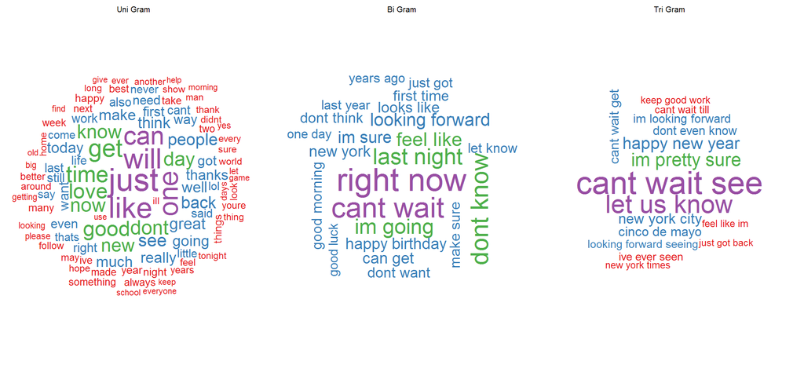

```r
par(mfrow = c(1, 3))
wordcloud(words = SortFreqMatrix$ST, freq = SortFreqMatrix$Freq,
          max.words=100, random.order=FALSE, colors = brewer.pal(4, "Set1"), main = "Uni Gram")
text(x=0.5, y=1.2, "Uni Gram")
wordcloud(words = SortFreqMatrix2$ST, freq = SortFreqMatrix2$Freq,
          max.words=100, random.order=FALSE, colors = brewer.pal(4, "Set1"), main = "Bi Gram")
text(x=0.5, y=1.2, "Bi Gram")
wordcloud(words = SortFreqMatrix3$ST, freq = SortFreqMatrix3$Freq,
          max.words=100, random.order=FALSE, colors = brewer.pal(4, "Set1"), main = "Tri Gram")
text(x=0.5, y=1.2, "Tri Gram")
```

Followed by bar plots of all three scenarios:

[figure not shown]

```r
par(mfrow = c(1, 3))
barplot(rev(SortFreqMatrix[1:15,]$Freq), las = 2, names.arg = SortFreqMatrix[1:15,]$ST,
        col ="darkblue", main ="Uni Gram",
        xlab = "Frequencies", horiz=TRUE)
barplot(rev(SortFreqMatrix2[1:15,]$Freq), las = 2, names.arg = SortFreqMatrix2[1:15,]$ST,
        col ="darkblue", main ="Bi Gram",
        xlab = "Frequencies", horiz=TRUE)
barplot(rev(SortFreqMatrix3[1:15,]$Freq), las = 2, names.arg = SortFreqMatrix3[1:15,]$ST,
        col ="darkblue", main ="Tri Gram",
        xlab = "Frequencies", horiz=TRUE)
```

## Next Steps

1. Build a predictive model based on the Term Document Matrices created above.
2. Build a data product to utilize the predictive model.
3. Build a slide deck promoting the data product.